# Chapter 5 - Stan

`r`r data(‘WaffleDivorce’, package = ‘rethinking’) d <- WaffleDivorce; rm(WaffleDivorce)

`r`r d <- d %>% mutate(MedianAgeMarriage_z = (MedianAgeMarriage - mean(MedianAgeMarriage)) / sd(MedianAgeMarriage), Marriage_z = (Marriage - mean(Marriage)) / sd(Marriage))

`stan`stan data { int<lower=0> N; vector[N] divorce; vector[N] median_age_z; } parameters { real a; real bA; real<lower=0, upper=10> sigma; } model { vector[N] mu = a + median_age_z * bA; target += normal_lpdf(divorce | mu, sigma);

target += normal_lpdf(a | 10, 10); target += normal_lpdf(bA | 0, 10); }

`stan`stan data{ int<lower=0> N; vector[N] divorce; vector[N] median_age_z; } parameters{ real a; real bA; real<lower=0, upper=10>sigma; } model{ vector[N] mu = a + median_age_z * bA; target += normal_lpdf(divorce| mu, sigma);

target+= normal_lpdf(a | 10, 10); target+= normal_lpdf(bA| 0, 1); }

`r`r data = list(N=nrow(d), divorce = d$Divorce, median_age_z = d$MedianAgeMarriage_z)

fit_5_1 = sampling(m05_1, data = data, iter = 1000, chains = 2, cores = 2)

`r`r print(fit_5_1, probs = c(0.10, 0.5, 0.9))

`stan`stan data{ int N; vector[N] divorce; vector[N] marriage_z; } parameters{ real a; real bM; real<lower=0> sigma; } model{ vector[N] mu = a + marriage_z * bM;

target += normal_lpdf(divorce | mu, sigma); target += normal_lpdf(a | 10, 10); target += normal_lpdf(bM | 0, 10); }

`r`r data = list(N = nrow(d), divorce = d$Divorce, marriage_z = d$Marriage_z)

fit_5_2 = sampling(m_5_2, data = data, iter = 1000, chains = 2, cores = 2)

`r`r print(fit_5_2, probs = c(0.10, 0.5, 0.9))

`stan`stan data{ int N; vector[N] divorce; vector[N] marriage_z; vector[N] median_age_z; } parameters{ real a; real bM; real bA; real<lower=0> sigma; } model{ vector[N] mu = a + marriage_z * bM + median_age_z * bA; target += normal_lpdf(divorce | mu, sigma); target += normal_lpdf(a | 10, 10); target += normal_lpdf(bM | 0, 10); target += normal_lpdf(bA | 0, 10); target += exponential_lpdf(sigma | 1); }

`r`r data = list(N = nrow(d), divorce = d$Marriage, marriage_z = d$Marriage_z, median_age_z = d$MedianAgeMarriage_z)

fit_5_3 = sampling(m_5_3, data = data, iter = 1000, chains = 2, cores = 2)

`r`r print(fit_5_3, probs = c(0.10, 0.5, 0.9))

`stan`stan data { int<lower=1> N; vector[N] A_z; vector[N] M_z; } parameters { real a; real b; real<lower=0> sigma; } model { vector[N] mu = a + A_z * b; target += normal_lpdf(M_z | mu, sigma); target += normal_lpdf(a | 0, 10); target += normal_lpdf(b | 0, 10); target += exponential_lpdf(sigma | 1); }

`r`r dat <- list( N = NROW(d), A_z = d$MedianAgeMarriage_z, M_z = d$Marriage_z )

fit05_4 <- sampling(m05_4, data = dat, iter = 1000, chains = 2, cores = 2)

# Chapter Questions

## Hard

### Q1

`r`r knitr::opts_chunk$set(echo = TRUE, warning = FALSE, message = FALSE, error = FALSE) library(dplyr); library(tidyr); library(rstan); library(skimr); library(ggplot2); library(ggthemes) theme_set(theme_tufte(base_family = ‘sans’))

df = read.csv(‘/Users/benjaminwee/Documents/courses/resources/Rethinking/Data/foxes.csv’)

`stan`stan data{ int<lower=1> N; vector[N] area; vector[N] weight; } parameters{ real a; real b; real<lower=0> sigma; } model{ vector[N] mu = a + area * b; target += normal_lpdf(weight | mu, sigma); target += normal_lpdf(a | 10, 10); target += normal_lpdf(b | 0, 1); target += exponential_lpdf(sigma | 1); }

`r`r dt <- list(N = nrow(df), weight = df$weight, area = df$area)

fit_m5h_1 <- sampling(m5h_1, data = dt, iter = 1000, chains = 2, cores = 2)

`r`r print(fit_m5h_1, probs = c(0.10, 0.5, 0.9))

```
Inference for Stan model: stan-1d7124078dfa.
2 chains, each with iter=1000; warmup=500; thin=1;
post-warmup draws per chain=500, total post-warmup draws=1000.

         mean se_mean   sd     10%     50%     90% n_eff Rhat
a        4.46    0.02 0.40    3.96    4.48    4.98   323 1.00
b        0.02    0.01 0.12   -0.13    0.02    0.18   329 1.00
sigma    1.19    0.00 0.07    1.10    1.19    1.28   512 1.00
lp__  -190.37    0.06 1.13 -191.95 -190.07 -189.28   337 1.01

Samples were drawn using NUTS(diag_e) at Sat Dec  7 16:44:27 2019.
For each parameter, n_eff is a crude measure of effective sample size,
and Rhat is the potential scale reduction factor on split chains (at
convergence, Rhat=1).
```

[figure not shown]

`stan`stan data{ int<lower=1> N; vector[N] groupsize; vector[N] weight; } parameters{ real a; real b_s; real<lower=1> sigma; } model{ vector[N] mu = a + groupsize * b_s; target += normal_lpdf(weight | mu, sigma); target += normal_lpdf(a | 10, 10); target += normal_lpdf(b_s | 0, 1); target += exponential_lpdf(sigma | 1); }

`r`r dt_h1_1 <- list(N = nrow(df), groupsize = df$groupsize, weight = df$weight)

fit_m5h_2 <- sampling(m5h_1_1, data = dt_h1_1, iter = 1000, chains = 2, cores = 2)

```
starting worker pid=8390 on localhost:11317 at 17:12:37.851
starting worker pid=8404 on localhost:11317 at 17:12:38.048
```

`r`r print(fit_m5h_2, probs = c(0.10, 0.5, 0.9))

```
Inference for Stan model: stan-1d7162a7e7ea.
2 chains, each with iter=1000; warmup=500; thin=1;
post-warmup draws per chain=500, total post-warmup draws=1000.

         mean se_mean   sd     10%     50%     90% n_eff Rhat
a        5.08    0.01 0.31    4.68    5.09    5.46   436 1.00
b_s     -0.13    0.00 0.07   -0.21   -0.13   -0.04   447 1.00
sigma    1.18    0.00 0.07    1.09    1.18    1.28   232 1.01
lp__  -190.89    0.09 1.26 -192.64 -190.58 -189.64   194 1.01

Samples were drawn using NUTS(diag_e) at Sat Dec  7 17:12:39 2019.
For each parameter, n_eff is a crude measure of effective sample size,
and Rhat is the potential scale reduction factor on split chains (at
convergence, Rhat=1).
```

[figure not shown]

### Q2

`stan`stan data{ int<lower=1> N; vector[N] groupsize; vector[N] area; vector[N] weight; } parameters{ real a; real b_s; real b_a; real<lower=1> sigma; } model{ vector[N] mu = a + groupsize * b_s + area * b_a; target += normal_lpdf(weight | mu, sigma); target += normal_lpdf(a | 10, 10); target += normal_lpdf(b_s | 0, 1); target += normal_lpdf(b_a | 0, 1); target += exponential_lpdf(sigma | 1); }

`r`r dt_h2 <- list(N = nrow(df), groupsize = df$groupsize, area = df$area, weight = df$weight)

fit_m5h2 <- sampling(m5h_2, data = dt_h2, iter = 1000, chains = 2, cores = 2)

```
starting worker pid=8729 on localhost:11317 at 17:33:32.286
starting worker pid=8743 on localhost:11317 at 17:33:32.498
```

`r`r print(fit_m5h2, probs = c(0.10, 0.5, 0.9))

```
Inference for Stan model: stan-1d711f8a7365.
2 chains, each with iter=1000; warmup=500; thin=1;
post-warmup draws per chain=500, total post-warmup draws=1000.

         mean se_mean   sd     10%     50%     90% n_eff Rhat
a        4.48    0.02 0.38    4.00    4.49    4.97   502    1
b_s     -0.41    0.00 0.12   -0.57   -0.41   -0.26   564    1
b_a      0.58    0.01 0.20    0.34    0.58    0.82   492    1
sigma    1.15    0.00 0.07    1.05    1.14    1.24   438    1
lp__  -188.25    0.09 1.47 -190.14 -187.90 -186.75   288    1

Samples were drawn using NUTS(diag_e) at Sat Dec  7 17:33:34 2019.
For each parameter, n_eff is a crude measure of effective sample size,
and Rhat is the potential scale reduction factor on split chains (at
convergence, Rhat=1).
```

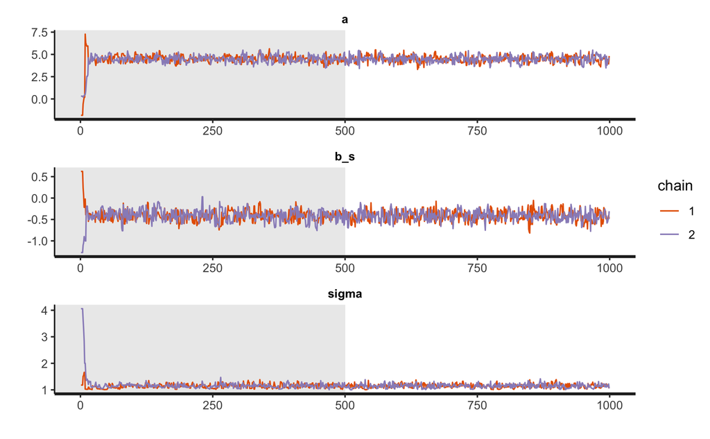

### Q3

`stan`stan data{ int<lower=1> N; vector[N] groupsize; vector[N] area; vector[N] avgfood; vector[N] weight; } parameters{ real a; real b_s; real b_a; real b_f; real<lower=1> sigma; } model{ vector[N] mu = a + groupsize * b_s + area * b_a + avgfood * b_f; target += normal_lpdf(weight | mu, sigma); target += normal_lpdf(a | 10, 10); target += normal_lpdf(b_s | 0, 1); target += normal_lpdf(b_a | 0, 1); target += normal_lpdf(b_f | 0, 1); target += exponential_lpdf(sigma | 1); }

`r`r dt_h3 <- list(N = nrow(df), groupsize = df$groupsize, area = df$area, avgfood = df$avgfood, weight = df$weight)

fit_m5h3 <- sampling(m5h_3, data = dt_h3, iter = 1000, chains = 2, cores = 2)

```
starting worker pid=9031 on localhost:11317 at 17:36:37.539
starting worker pid=9045 on localhost:11317 at 17:36:37.733
```

`r`r print(fit_m5h3, probs = c(0.10, 0.5, 0.9))

```
Inference for Stan model: stan-1d713c649dc5.
2 chains, each with iter=1000; warmup=500; thin=1;
post-warmup draws per chain=500, total post-warmup draws=1000.

         mean se_mean   sd     10%     50%     90% n_eff Rhat
a        4.35    0.02 0.42    3.82    4.35    4.88   352 1.00
b_s     -0.48    0.01 0.14   -0.66   -0.47   -0.29   429 1.01
b_a      0.53    0.01 0.22    0.25    0.52    0.82   374 1.01
b_f      0.77    0.04 0.85   -0.30    0.77    1.89   557 1.00
sigma    1.14    0.00 0.07    1.05    1.13    1.24   586 1.00
lp__  -189.45    0.08 1.70 -191.62 -189.14 -187.62   422 1.00

Samples were drawn using NUTS(diag_e) at Sat Dec  7 17:36:39 2019.
For each parameter, n_eff is a crude measure of effective sample size,
and Rhat is the potential scale reduction factor on split chains (at
convergence, Rhat=1).
```

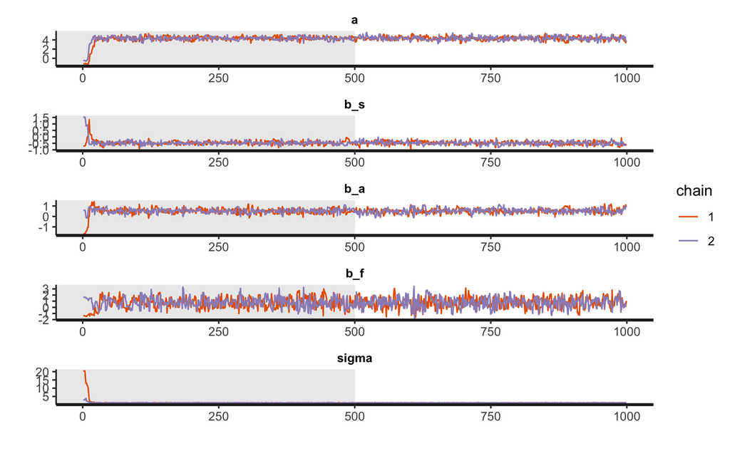